# R Notebook

```r
library(biscale)
library(cleangeo)
library(cowplot)
library(dplyr)
library(geosphere)
library(ggplot2)
library(maps)
library(maptools)
library(rgdal)
library(rgeos)
library(sf)
library(sp)
library(spatialreg)
library(spdep)
library(tidyr)
```

```r
data <- read.csv('./Data/childpov18_southfull.csv',
                 colClasses = c("character", "character", "character",
                                "numeric", "numeric", "numeric", "numeric",
                                "numeric", "numeric", "numeric", "numeric",
                                "numeric", "numeric", "numeric", "numeric",
                                "numeric", "numeric", "numeric", "numeric",
                                "numeric", "numeric", "numeric", "numeric",
                                "numeric", "numeric", "numeric", "numeric",
                                "numeric", "numeric", "numeric", "numeric",
                                "numeric", "numeric", "numeric", "numeric"))
```

```r
View(data)
```

```r
names(data)[names(data)=="X2016.child.poverty"] <- "child.pov.2016"
```

Subset data for information from the state of Florida

```r
fl_pov <- data %>% subset(State == "FL")
```

checking data for any missing data or errors

```r
summary(fl_pov)
```

```
     FIPS              State           County_Name          Longitude         Latitude     child.pov.2016 unemployment_13   per_lhs_13     per_black_13
 Length:67          Length:67          Length:67          Min.   :-87.37   Min.   :25.49   Min.   : 9.5   Min.   : 4.80   Min.   : 6.80   Min.   : 2.879
 Class :character   Class :character   Class :character   1st Qu.:-83.53   1st Qu.:27.59   1st Qu.:19.8   1st Qu.: 6.70   1st Qu.:12.15   1st Qu.: 8.564
 Mode  :character   Mode  :character   Mode  :character   Median :-82.30   Median :29.46   Median :24.8   Median : 7.50   Median :14.80   Median :12.026
                                                          Mean   :-82.70   Mean   :28.95   Mean   :25.8   Mean   : 7.53   Mean   :16.89   Mean   :14.156
                                                          3rd Qu.:-81.34   3rd Qu.:30.27   3rd Qu.:30.3   3rd Qu.: 8.20   3rd Qu.:21.55   3rd Qu.:17.316
                                                          Max.   :-80.45   Max.   :30.87   Max.   :43.2   Max.   :11.90   Max.   :35.90   Max.   :55.038
 per_hispanic_13    per_ag_13       per_construction_13 per_manufacturing_13 per_retail_13    per_healthss_13 per_singlemom_13     urban
 Min.   : 2.165   Min.   : 0.2472   Min.   : 3.547      Min.   : 0.5988      Min.   : 4.824   Min.   :13.20   Min.   : 3.106   Min.   :0.0000
 1st Qu.: 4.991   1st Qu.: 0.6878   1st Qu.: 6.059      1st Qu.: 4.2823      1st Qu.:11.572   1st Qu.:19.53   1st Qu.: 8.235   1st Qu.:0.0000
 Median : 8.461   Median : 1.5255   Median : 7.078      Median : 4.9995      Median :12.984   Median :21.53   Median : 9.851   Median :1.0000
 Mean   :12.773   Mean   : 4.0100   Mean   : 7.329      Mean   : 5.7126      Mean   :12.884   Mean   :21.55   Mean   : 9.905   Mean   :0.6567
 3rd Qu.:17.251   3rd Qu.: 4.7649   3rd Qu.: 8.434      3rd Qu.: 6.4280      3rd Qu.:14.519   3rd Qu.:23.44   3rd Qu.:11.628   3rd Qu.:1.0000
 Max.   :64.862   Max.   :32.9980   Max.   :13.496      Max.   :18.1385      Max.   :17.608   Max.   :38.73   Max.   :15.867   Max.   :1.0000
     rural           lnchildpov    lnunemployment     lnlesshs        lnblack        lnhispanic          lnag         lnconstruction  lnmanufacturing
 Min.   :0.00000   Min.   :2.251   Min.   :1.569   Min.   :1.917   Min.   :1.058   Min.   :0.7723   Min.   :-1.3974   Min.   :1.266   Min.   :-0.5128
 1st Qu.:0.00000   1st Qu.:2.986   1st Qu.:1.902   1st Qu.:2.497   1st Qu.:2.147   1st Qu.:1.6076   1st Qu.:-0.3743   1st Qu.:1.801   1st Qu.: 1.4544
 Median :0.00000   Median :3.211   Median :2.015   Median :2.695   Median :2.487   Median :2.1355   Median : 0.4223   Median :1.957   Median : 1.6093
 Mean   :0.02985   Mean   :3.199   Mean   :2.004   Mean   :2.752   Mean   :2.468   Mean   :2.2209   Mean   : 0.6201   Mean   :1.956   Mean   : 1.6457
 3rd Qu.:0.00000   3rd Qu.:3.411   3rd Qu.:2.104   3rd Qu.:3.070   3rd Qu.:2.852   3rd Qu.:2.8476   3rd Qu.: 1.5612   3rd Qu.:2.132   3rd Qu.: 1.8606
 Max.   :1.00000   Max.   :3.766   Max.   :2.477   Max.   :3.581   Max.   :4.008   Max.   :4.1723   Max.   : 3.4964   Max.   :2.602   Max.   : 2.8980
    lnretail       lnhealthss     lnsinglemom      lnchpov17      lnuninsured    lnincome_ratio  lnsevere_housing  lnteenbirth     lnunmarried
 Min.   :1.574   Min.   :2.580   Min.   :1.133   Min.   :2.230   Min.   :2.682   Min.   :1.324   Min.   :2.269    Min.   :2.833   Min.   :0.010
 1st Qu.:2.449   1st Qu.:2.972   1st Qu.:2.108   1st Qu.:2.960   1st Qu.:2.989   1st Qu.:1.400   1st Qu.:2.748    1st Qu.:3.547   1st Qu.:3.507
 Median :2.564   Median :3.070   Median :2.288   Median :3.127   Median :3.069   Median :1.483   Median :2.902    Median :3.818   Median :3.653
 Mean   :2.536   Mean   :3.056   Mean   :2.256   Mean   :3.160   Mean   :3.095   Mean   :1.495   Mean   :2.896    Mean   :3.831   Mean   :3.580
 3rd Qu.:2.675   3rd Qu.:3.155   3rd Qu.:2.453   3rd Qu.:3.434   3rd Qu.:3.201   3rd Qu.:1.560   3rd Qu.:3.043    3rd Qu.:4.106   3rd Qu.:3.858
 Max.   :2.868   Max.   :3.657   Max.   :2.764   Max.   :3.940   Max.   :3.503   Max.   :1.840   Max.   :3.500    Max.   :4.536   Max.   :4.505
```

# First let’s start with Ordinary Least Squares

```r
equation <- child.pov.2016 ~ rural + urban + lnmanufacturing + lnag +
  lnretail + lnhealthss + lnconstruction + lnlesshs +
  lnunemployment + lnsinglemom + lnblack + lnhispanic +
  lnuninsured + lnincome_ratio + lnteenbirth + lnunmarried
```

limit set for numbers greater than 5 decimal places in the output and summaries

```r
options(scipen = 5)
```

```r
ols <- lm(equation, data=fl_pov)
summary(ols)
```

```
Call:
lm(formula = equation, data = fl_pov)

Residuals:
     Min       1Q   Median       3Q      Max
-21.5357  -2.1319   0.0606   3.2863   7.9391

Coefficients:
                 Estimate Std. Error t value Pr(>|t|)
(Intercept)     -90.98435   33.86566  -2.687  0.00977 **
rural           -10.79332   13.65817  -0.790  0.43312
urban            -2.12635    2.78053  -0.765  0.44803
lnmanufacturing   0.01683    1.94885   0.009  0.99314
lnag              1.62445    1.25335   1.296  0.20090
lnretail          4.06307    4.70995   0.863  0.39245
lnhealthss        6.91556    6.16230   1.122  0.26712
lnconstruction    4.21861    3.58955   1.175  0.24546
lnlesshs          5.80446    4.47108   1.298  0.20017
lnunemployment    4.49477    7.36454   0.610  0.54441
lnsinglemom       2.16433    4.04671   0.535  0.59513
lnblack           0.72746    1.89375   0.384  0.70251
lnhispanic       -0.69094    2.16398  -0.319  0.75084
lnuninsured       9.71712    9.87077   0.984  0.32964
lnincome_ratio    6.90062    7.97192   0.866  0.39084
lnteenbirth       1.57326    2.07719   0.757  0.45237
lnunmarried       0.34605    3.31773   0.104  0.91735
---
Signif. codes:  0 ‘***’ 0.001 ‘**’ 0.01 ‘*’ 0.05 ‘.’ 0.1 ‘ ’ 1

Residual standard error: 5.917 on 50 degrees of freedom
Multiple R-squared:  0.5971,    Adjusted R-squared:  0.4682
F-statistic: 4.632 on 16 and 50 DF,  p-value: 0.00001488
```

#Creating a list of contiguity neighbors Used to determine any spatial relationships in the residuals. In order to create a county polygon using data from Federal Information Processing Standards codes (FIPS).

```r
fips <- county.fips
fips.codes <- separate(data = fips, col = polyname, into = c("state", "county"), sep = ",")
fl_fips <- subset(fips.codes, state=="florida", select=fips)

florida <- map(database = "county", regions = "florida", fill=T, plot=F)
fl_sp = map2SpatialPolygons(florida,fl_fips$fips,CRS("+proj=longlat"))
```

```r
require(maptools)
sf::sf_use_s2(FALSE)
```

```
Spherical geometry (s2) switched off
```

cleangeo like janitor, but for spatial data

```r
file <- system.file("extdata", "example.shp", package = "cleangeo")
sp <- readShapePoly(file)
 cleaned <- clgeo_Clean(fl_sp)
```

[output not shown]

[output cut: 13 more lines]

[output not shown]

```r
 report.clean <- clgeo_CollectionReport(cleaned)
 clgeo_SummaryReport(report.clean)
```

```
   type     valid         issue_type
 NA's:67   Mode:logical   NA's:67
           TRUE:67
```

```r
neighb.data <- poly2nb(cleaned, queen=T)
```

```
although coordinates are longitude/latitude, st_intersects assumes that they are planar
```

```r
cont.neighb <- nb2listw(neighb.data,style="W", zero.policy = TRUE)
```

Now that we have created a spatial dataset and a list of neighbors, we can determine if there is any residual spatial dependence. # Moran’s Correlation and LaGrange Multiplier Tests

examines residuals of the OLS regression with a sptial relationship matrix

```r
lm.morantest(ols, cont.neighb)
```

```
    Global Moran I for regression residuals

data:
model: lm(formula = equation, data = fl_pov)
weights: cont.neighb

Moran I statistic standard deviate = 2.4161, p-value = 0.007844
alternative hypothesis: greater
sample estimates:
Observed Moran I      Expectation         Variance
     0.138362502     -0.050573743      0.006115038
```

Looking above, we can see a significant p-value of 0.007844, so we would reject the null hypothesis that says there is no spatial correlation in the residuals.

**This would suggest we should be using a spatial model.

#LaGrange Multiplier Test

```r
lm.LMtests(ols, cont.neighb, test="all")
```

```
    Lagrange multiplier diagnostics for spatial dependence

data:
model: lm(formula = equation, data = fl_pov)
weights: cont.neighb

LMerr = 2.6928, df = 1, p-value = 0.1008


    Lagrange multiplier diagnostics for spatial dependence

data:
model: lm(formula = equation, data = fl_pov)
weights: cont.neighb

LMlag = 1.2994, df = 1, p-value = 0.2543


    Lagrange multiplier diagnostics for spatial dependence

data:
model: lm(formula = equation, data = fl_pov)
weights: cont.neighb

RLMerr = 1.526, df = 1, p-value = 0.2167


    Lagrange multiplier diagnostics for spatial dependence

data:
model: lm(formula = equation, data = fl_pov)
weights: cont.neighb

RLMlag = 0.13272, df = 1, p-value = 0.7156


    Lagrange multiplier diagnostics for spatial dependence

data:
model: lm(formula = equation, data = fl_pov)
weights: cont.neighb

SARMA = 2.8255, df = 2, p-value = 0.2435
```

The results show:

LMerr LMlag RLMerr RLMlag SARMA

0.1008 0.2543 0.2167 0.7156 0.2435

Closest model would be LMerr with a p-value of 0.1008, but is still high

# Spatially lagged X Model

```r
SLX.model <- spatialreg::lmSLX(equation, data=fl_pov, cont.neighb)
summary(SLX.model)
```

```
Call:
lm(formula = formula(paste("y ~ ", paste(colnames(x)[-1], collapse = "+"))),
    data = as.data.frame(x), weights = weights)

Residuals:
     Min       1Q   Median       3Q      Max
-14.9927  -2.0568  -0.0043   2.4013   7.4728

Coefficients:
                      Estimate Std. Error t value Pr(>|t|)
(Intercept)         -107.77849  128.12757  -0.841   0.4061
rural                 -5.76269   18.61433  -0.310   0.7588
urban                 -1.54521    3.73365  -0.414   0.6816
lnmanufacturing       -2.62664    2.60719  -1.007   0.3208
lnag                   1.80951    1.44226   1.255   0.2182
lnretail               0.82431    5.49114   0.150   0.8816
lnhealthss            -3.85507    7.94030  -0.486   0.6304
lnconstruction         5.41070    4.41202   1.226   0.2285
lnlesshs               1.91850    5.57862   0.344   0.7330
lnunemployment         9.11259   10.34407   0.881   0.3845
lnsinglemom            5.08905    5.23966   0.971   0.3383
lnblack                0.86955    2.38109   0.365   0.7172
lnhispanic            -0.02924    3.09028  -0.009   0.9925
lnuninsured            1.83023   12.64017   0.145   0.8857
lnincome_ratio        10.37007    9.54845   1.086   0.2851
lnteenbirth            2.31784    2.54917   0.909   0.3696
lnunmarried            1.28510    4.63295   0.277   0.7832
lag.rural            -12.26697   34.62787  -0.354   0.7253
lag.urban             -9.11103    8.40301  -1.084   0.2859
lag.lnmanufacturing    3.97812    5.90102   0.674   0.5048
lag.lnag               1.84862    3.15880   0.585   0.5623
lag.lnretail          24.12769   13.32925   1.810   0.0791 .
lag.lnhealthss        25.66410   17.09610   1.501   0.1425
lag.lnconstruction    -1.68061   11.71790  -0.143   0.8868
lag.lnlesshs           3.49059   13.26319   0.263   0.7940
lag.lnunemployment   -15.86400   20.88975  -0.759   0.4528
lag.lnsinglemom       -4.08135   12.64943  -0.323   0.7489
lag.lnblack           -1.86342    5.52750  -0.337   0.7381
lag.lnhispanic         2.72957    6.45089   0.423   0.6749
lag.lnuninsured      -11.81837   31.32179  -0.377   0.7083
lag.lnincome_ratio    -7.79462   22.29783  -0.350   0.7288
lag.lnteenbirth        2.52898    5.77249   0.438   0.6641
lag.lnunmarried       -1.09233    9.15226  -0.119   0.9057
---
Signif. codes:  0 ‘***’ 0.001 ‘**’ 0.01 ‘*’ 0.05 ‘.’ 0.1 ‘ ’ 1

Residual standard error: 5.725 on 34 degrees of freedom
Multiple R-squared:  0.7435,    Adjusted R-squared:  0.5021
F-statistic:  3.08 on 32 and 34 DF,  p-value: 0.0008246
```

Note p-value of this model is significant, but no variables stick out here, except retail with a p-value of 0.079

```r
summary(spatialreg::impacts(SLX.model, cont.neighb), zstats = TRUE)[["pzmat"]]
```

```
                   Direct  Indirect     Total
rural           0.7568776 0.7231506 0.6629451
urban           0.6789763 0.2782505 0.3093468
lnmanufacturing 0.3137132 0.5002216 0.8369565
lnag            0.2096115 0.5583953 0.2962940
lnretail        0.8806733 0.0702754 0.1089580
lnhealthss      0.6273167 0.1333123 0.1616722
lnconstruction  0.2200653 0.8859567 0.7868536
lnlesshs        0.7309193 0.7924129 0.6856755
lnunemployment  0.3783459 0.4476043 0.7472062
lnsinglemom     0.3314208 0.7469595 0.9431870
lnblack         0.7149698 0.7360284 0.8782394
lnhispanic      0.9924503 0.6722002 0.6790580
lnuninsured     0.8848728 0.7059351 0.7659406
lnincome_ratio  0.2774579 0.7266627 0.9201027
lnteenbirth     0.3632155 0.6613069 0.4897173
lnunmarried     0.7814867 0.9049970 0.9868011
```

Not much to see above.

#Spatial Lag Model

```r
sp.lag.model <- spatialreg::lagsarlm(equation, data=fl_pov, cont.neighb)
summary(sp.lag.model, Nagelkerke = TRUE)
```

```
Call:spatialreg::lagsarlm(formula = equation, data = fl_pov, listw = cont.neighb)

Residuals:
       Min         1Q     Median         3Q        Max
-21.393219  -2.298661   0.081436   3.451123   8.622888

Type: lag
Coefficients: (asymptotic standard errors)
                 Estimate Std. Error z value Pr(>|z|)
(Intercept)     -87.04223   28.87946 -3.0140 0.002578
rural            -9.97734   11.57589 -0.8619 0.388739
urban            -1.51848    2.36398 -0.6423 0.520652
lnmanufacturing  -0.49291    1.65183 -0.2984 0.765397
lnag              1.30377    1.06584  1.2232 0.221245
lnretail          2.59973    4.01568  0.6474 0.517377
lnhealthss        4.48096    5.29580  0.8461 0.397478
lnconstruction    4.19502    3.04401  1.3781 0.168166
lnlesshs          6.01418    3.78942  1.5871 0.112490
lnunemployment    6.42540    6.29793  1.0202 0.307614
lnsinglemom       2.92494    3.46392  0.8444 0.398444
lnblack           0.85063    1.61179  0.5278 0.597669
lnhispanic       -0.75509    1.83410 -0.4117 0.680562
lnuninsured       8.30324    8.49835  0.9770 0.328549
lnincome_ratio    7.23122    6.75731  1.0701 0.284560
lnteenbirth       1.37470    1.76359  0.7795 0.435693
lnunmarried       0.45913    2.81190  0.1633 0.870296

Rho: 0.22107, LR test value: 1.7787, p-value: 0.18231
Asymptotic standard error: 0.1304
    z-value: 1.6953, p-value: 0.090027
Wald statistic: 2.8739, p-value: 0.090027

Log likelihood: -203.4871 for lag model
ML residual variance (sigma squared): 25.147, (sigma: 5.0147)
Nagelkerke pseudo-R-squared: 0.60768
Number of observations: 67
Number of parameters estimated: 19
AIC: 444.97, (AIC for lm: 444.75)
LM test for residual autocorrelation
test value: 4.1081, p-value: 0.042678
```

```r
summary(spatialreg::impacts(sp.lag.model, listw = cont.neighb, R=100), zstats = TRUE)[["pzmat"]]
```

```
                   Direct  Indirect     Total
rural           0.2782692 0.4178682 0.2807752
urban           0.4446946 0.5901587 0.4618416
lnmanufacturing 0.8600099 0.9043377 0.8677729
lnag            0.1818370 0.3818252 0.2001387
lnretail        0.5296757 0.7317273 0.5634662
lnhealthss      0.4401604 0.6276414 0.4663816
lnconstruction  0.2038767 0.4427560 0.2275521
lnlesshs        0.1048894 0.3833572 0.1309252
lnunemployment  0.2676326 0.4648773 0.2981827
lnsinglemom     0.3355272 0.4839315 0.3426026
lnblack         0.6985340 0.8267323 0.7208149
lnhispanic      0.5983115 0.6395129 0.5942445
lnuninsured     0.3159929 0.5039849 0.3401816
lnincome_ratio  0.2422630 0.3513888 0.2371041
lnteenbirth     0.4594133 0.5902795 0.4748652
lnunmarried     0.9525207 0.9337710 0.9459838
```

#Spatial Error Model

```r
sp.err.model <- spatialreg::errorsarlm(equation, data=fl_pov, cont.neighb)
summary(sp.err.model, Nagelkerke = TRUE)
```

```
Call:spatialreg::errorsarlm(formula = equation, data = fl_pov, listw = cont.neighb)

Residuals:
      Min        1Q    Median        3Q       Max
-18.89049  -1.92268   0.22525   2.60905   9.22989

Type: error
Coefficients: (asymptotic standard errors)
                 Estimate Std. Error z value Pr(>|z|)
(Intercept)     -77.65217   28.86801 -2.6899 0.007147
rural            -4.66943   10.83498 -0.4310 0.666498
urban            -0.57803    2.06319 -0.2802 0.779351
lnmanufacturing  -2.41776    1.61501 -1.4971 0.134378
lnag              0.98122    1.00138  0.9799 0.327151
lnretail         -0.34792    3.51838 -0.0989 0.921228
lnhealthss        1.19510    5.39773  0.2214 0.824776
lnconstruction    4.62089    2.72070  1.6984 0.089428
lnlesshs          5.88513    3.54609  1.6596 0.096993
lnunemployment    8.59968    6.31854  1.3610 0.173506
lnsinglemom       2.55664    3.27098  0.7816 0.434442
lnblack           1.97198    1.44762  1.3622 0.173127
lnhispanic       -0.65460    1.96938 -0.3324 0.739596
lnuninsured      10.10061    8.32074  1.2139 0.224783
lnincome_ratio    8.34966    6.09057  1.3709 0.170401
lnteenbirth       1.33029    1.52156  0.8743 0.381957
lnunmarried       1.14786    2.50481  0.4583 0.646764

Lambda: 0.57064, LR test value: 7.6314, p-value: 0.0057362
Asymptotic standard error: 0.11507
    z-value: 4.9589, p-value: 0.00000070897
Wald statistic: 24.591, p-value: 0.00000070897

Log likelihood: -200.5607 for error model
ML residual variance (sigma squared): 21.287, (sigma: 4.6137)
Nagelkerke pseudo-R-squared: 0.6405
Number of observations: 67
Number of parameters estimated: 19
AIC: 439.12, (AIC for lm: 444.75)
```

Note significant p-value

```r
spatialreg::Hausman.test(sp.err.model)
```

```
    Spatial Hausman test (asymptotic)

data:  NULL
Hausman test = 15.559, df = 17, p-value = 0.5553
```

The Hausman test resulted in a high p-value of 0.5553, which would fail to reject the null hypothesis that spatial error model is needed.

#Spatial Durbin Error Model The Spatial Durbin Error Model contains components of OLS, SLX, and Spatial Error models.

```r
sd.err <- spatialreg::errorsarlm(equation, fl_pov, cont.neighb, etype = "emixed")
sdm <- spatialreg::lagsarlm(equation, fl_pov, cont.neighb, type = "mixed")
```

Remembering that the Spatial Durbin Error Model is a local model which includes the errors and lag x values, we can view a summary of that model.

```r
summary(sd.err, Nagelkerke = TRUE)
```

```
Call:spatialreg::errorsarlm(formula = equation, data = fl_pov, listw = cont.neighb,     etype = "emixed")

Residuals:
     Min       1Q   Median       3Q      Max
-13.0540  -2.7501   0.1192   2.4125   6.6689

Type: error
Coefficients: (asymptotic standard errors)
                     Estimate Std. Error z value Pr(>|z|)
(Intercept)         -66.36229   86.92271 -0.7635 0.445187
rural                -7.46181   13.70401 -0.5445 0.586098
urban                -2.34505    2.56066 -0.9158 0.359772
lnmanufacturing      -3.42804    1.85339 -1.8496 0.064370
lnag                  1.78271    1.03683  1.7194 0.085545
lnretail              0.47045    3.75805  0.1252 0.900378
lnhealthss           -5.62065    5.79588 -0.9698 0.332163
lnconstruction        5.78170    3.06341  1.8873 0.059114
lnlesshs              0.59343    3.86048  0.1537 0.877832
lnunemployment       10.35068    7.35782  1.4068 0.159499
lnsinglemom           4.59901    3.76958  1.2200 0.222452
lnblack               0.91187    1.68161  0.5423 0.587636
lnhispanic            0.22939    2.26785  0.1011 0.919434
lnuninsured           3.01887    9.30083  0.3246 0.745499
lnincome_ratio       12.56086    6.55894  1.9151 0.055483
lnteenbirth           3.10961    1.72023  1.8077 0.070658
lnunmarried           0.91490    3.36565  0.2718 0.785750
lag.rural           -24.82528   24.48394 -1.0139 0.310611
lag.urban            -9.42667    5.86477 -1.6073 0.107981
lag.lnmanufacturing   2.72568    4.28129  0.6366 0.524353
lag.lnag              2.01369    2.18165  0.9230 0.356001
lag.lnretail         26.55530    8.72364  3.0441 0.002334
lag.lnhealthss       26.52600   11.77224  2.2533 0.024242
lag.lnconstruction   -5.27437    8.19452 -0.6436 0.519805
lag.lnlesshs          8.75007    9.05500  0.9663 0.333881
lag.lnunemployment  -14.32580   14.51160 -0.9872 0.323547
lag.lnsinglemom      -8.00408    8.70547 -0.9194 0.357870
lag.lnblack          -0.06083    3.65177 -0.0167 0.986710
lag.lnhispanic        4.06342    4.85157  0.8375 0.402285
lag.lnuninsured     -24.73316   22.72526 -1.0884 0.276438
lag.lnincome_ratio  -15.14975   14.74081 -1.0277 0.304071
lag.lnteenbirth       3.65333    3.91610  0.9329 0.350872
lag.lnunmarried      -3.79596    6.31737 -0.6009 0.547922

Lambda: -0.42012, LR test value: 1.8444, p-value: 0.17444
Asymptotic standard error: 0.18106
    z-value: -2.3203, p-value: 0.020325
Wald statistic: 5.3838, p-value: 0.020325

Log likelihood: -188.3277 for error model
ML residual variance (sigma squared): 15.577, (sigma: 3.9468)
Nagelkerke pseudo-R-squared: 0.75047
Number of observations: 67
Number of parameters estimated: 35
AIC: 446.66, (AIC for lm: 446.5)
```

Model not significant with a p-value of 0.17444, but we do see some significance with variables: construction, income ratio, retail, and healthss

Examining the impacts matrix as we have before we can determine if the Spatial Durbin Error Model is the most appropriate model for our data or if we should restrict the model to a spatial error, SLX, or OLS model.

```r
summary(spatialreg::impacts(sd.err, listw = cont.neighb, R = 100), zstats = TRUE)[["pzmat"]]
```

```
                    Direct    Indirect       Total
rural           0.58609834 0.310610777 0.233732864
urban           0.35977182 0.107980513 0.083569441
lnmanufacturing 0.06437047 0.524352981 0.873096624
lnag            0.08554457 0.356001048 0.085977072
lnretail        0.90037774 0.002334084 0.003892412
lnhealthss      0.33216303 0.024242357 0.028273091
lnconstruction  0.05911435 0.519805087 0.955382668
lnlesshs        0.87783181 0.333881447 0.259167548
lnunemployment  0.15949885 0.323546578 0.761982837
lnsinglemom     0.22245213 0.357869941 0.710871911
lnblack         0.58763642 0.986709766 0.831126928
lnhispanic      0.91943410 0.402284986 0.348910928
lnuninsured     0.74549861 0.276438213 0.345146270
lnincome_ratio  0.05548308 0.304071161 0.868272521
lnteenbirth     0.07065765 0.350871871 0.123940227
lnunmarried     0.78574960 0.547922152 0.707495941
```

*** This model did however, produce significant results for variables retail and healthss,

This will help us test the HO that we should restrict the model to a more simple model. The first step is to determine if we should restrict the model from a Spatial Durbin Error model to a spatial error mode.

```r
LR.Sarlm(sd.err,sp.err.model)
```

```
    Likelihood ratio for spatial linear models

data:
Likelihood ratio = 24.466, df = 16, p-value = 0.07981
sample estimates:
      Log likelihood of sd.err Log likelihood of sp.err.model
                     -188.3277                      -200.5607
```

For this model, we would fail to reject the null hypothesis with a p-value of 0.079

#Creating a list of K-neighbors

reate xy data from the polygons

```r
all.xy <-centroid(fl_sp)
colnames(all.xy) <- c("x","y")
```

We will examine k = 1, k = 3, and k = 5. Then we need to calculate the distance value so the model can create a radius to encompass the neighbors. Finally, we need to produce the list of neighbors within the neighborhood.

```r
#Create neighbors
all.dist.k1 <- knn2nb(knearneigh(all.xy, k=1, longlat = TRUE))
all.dist.k3 <- knn2nb(knearneigh(all.xy, k=3, longlat = TRUE))
all.dist.k5 <- knn2nb(knearneigh(all.xy, k=5, longlat = TRUE))
all.dist.k9 <- knn2nb(knearneigh(all.xy, k=9, longlat = TRUE))

#Determine max k distance value to neighbor
all.max.k1 <- max(unlist(nbdists(all.dist.k1, all.xy, longlat=TRUE)))
all.max.k3 <- max(unlist(nbdists(all.dist.k3, all.xy, longlat=TRUE)))
all.max.k5 <- max(unlist(nbdists(all.dist.k5, all.xy, longlat=TRUE)))
all.max.k9 <- max(unlist(nbdists(all.dist.k9, all.xy, longlat=TRUE)))

#Calculate neighbors based on distance
all.sp.dist.k1 <- dnearneigh(all.xy, d1=0, d2=1 * all.max.k1, longlat = TRUE)
all.sp.dist.k3 <- dnearneigh(all.xy, d1=0, d2=1 * all.max.k3, longlat = TRUE)
all.sp.dist.k5 <- dnearneigh(all.xy, d1=0, d2=1 * all.max.k5, longlat = TRUE)
all.sp.dist.k9 <- dnearneigh(all.xy, d1=0, d2=1 * all.max.k9, longlat = TRUE)

#Create neighbor list
all.dist.neighb.k1 <- nb2listw(all.sp.dist.k1,style="W", zero.policy = TRUE)
all.dist.neighb.k3 <- nb2listw(all.sp.dist.k3,style="W", zero.policy = TRUE)
all.dist.neighb.k5 <- nb2listw(all.sp.dist.k5,style="W", zero.policy = TRUE)
all.dist.neighb.k9 <- nb2listw(all.sp.dist.k9,style="W", zero.policy = TRUE)
```

#Distance Lab Model

calculating distance for k=1, k=3, and k=5

```r
all.dist.lag.k1 <- spatialreg::lagsarlm(equation, data = fl_pov, listw = all.dist.neighb.k1)
all.dist.lag.k3 <- spatialreg::lagsarlm(equation, data = fl_pov, listw = all.dist.neighb.k3)
all.dist.lag.k5 <- spatialreg::lagsarlm(equation, data = fl_pov, listw = all.dist.neighb.k5)
all.dist.lag.k9 <- spatialreg::lagsarlm(equation, data = fl_pov, listw = all.dist.neighb.k9)
```

Summary for k=1

```r
summary(all.dist.lag.k1, Nagelkerke = TRUE)
```

```
Call:spatialreg::lagsarlm(formula = equation, data = fl_pov, listw = all.dist.neighb.k1)

Residuals:
       Min         1Q     Median         3Q        Max
-21.439700  -2.255317   0.038032   3.237488   8.238631

Type: lag
Coefficients: (asymptotic standard errors)
                 Estimate Std. Error z value Pr(>|z|)
(Intercept)     -91.06519   29.10108 -3.1293 0.001752
rural            -9.85041   11.73568 -0.8394 0.401270
urban            -1.94268    2.39254 -0.8120 0.416807
lnmanufacturing  -0.14354    1.67456 -0.0857 0.931691
lnag              1.42989    1.08824  1.3139 0.188865
lnretail          3.68119    4.04557  0.9099 0.362859
lnhealthss        5.93190    5.33416  1.1121 0.266113
lnconstruction    4.38651    3.08358  1.4225 0.154870
lnlesshs          5.86788    3.84355  1.5267 0.126840
lnunemployment    5.26110    6.34438  0.8293 0.406961
lnsinglemom       2.47765    3.49280  0.7094 0.478101
lnblack           0.83466    1.62787  0.5127 0.608138
lnhispanic       -0.61968    1.86082 -0.3330 0.739121
lnuninsured       8.76861    8.60513  1.0190 0.308204
lnincome_ratio    7.43093    6.84848  1.0850 0.277900
lnteenbirth       1.59892    1.78488  0.8958 0.370352
lnunmarried       0.51649    2.85081  0.1812 0.856232

Rho: 0.09843, LR test value: 0.55789, p-value: 0.45511
Asymptotic standard error: 0.11065
    z-value: 0.88956, p-value: 0.3737
Wald statistic: 0.79132, p-value: 0.3737

Log likelihood: -204.0975 for lag model
ML residual variance (sigma squared): 25.827, (sigma: 5.082)
Nagelkerke pseudo-R-squared: 0.60046
Number of observations: 67
Number of parameters estimated: 19
AIC: 446.19, (AIC for lm: 444.75)
LM test for residual autocorrelation
test value: 3.5943, p-value: 0.057977
```

For k=1, there is a high p-value of 0.455.

Now summary for k=3

```r
summary(all.dist.lag.k3, Nagelkerke = TRUE)
```

```
Call:spatialreg::lagsarlm(formula = equation, data = fl_pov, listw = all.dist.neighb.k3)

Residuals:
       Min         1Q     Median         3Q        Max
-21.590815  -1.883141   0.025802   3.038713   8.046561

Type: lag
Coefficients: (asymptotic standard errors)
                 Estimate Std. Error z value Pr(>|z|)
(Intercept)     -85.51925   29.56018 -2.8931 0.003815
rural           -11.46826   11.76901 -0.9744 0.329835
urban            -2.15439    2.39926 -0.8979 0.369219
lnmanufacturing   0.12118    1.68301  0.0720 0.942600
lnag              1.72588    1.08144  1.5959 0.110509
lnretail          4.17542    4.05311  1.0302 0.302927
lnhealthss        7.50344    5.30319  1.4149 0.157100
lnconstruction    4.04843    3.08893  1.3106 0.189984
lnlesshs          5.91115    3.85660  1.5327 0.125341
lnunemployment    4.12892    6.34220  0.6510 0.515032
lnsinglemom       2.06864    3.48639  0.5933 0.552950
lnblack           0.66404    1.63151  0.4070 0.684000
lnhispanic       -0.77434    1.87479 -0.4130 0.679586
lnuninsured       9.86235    8.59990  1.1468 0.251465
lnincome_ratio    5.99832    6.86100  0.8743 0.381975
lnteenbirth       1.50597    1.78900  0.8418 0.399903
lnunmarried       0.10519    2.86488  0.0367 0.970711

Rho: -0.16616, LR test value: 0.35553, p-value: 0.551
Asymptotic standard error: 0.22566
    z-value: -0.73635, p-value: 0.46152
Wald statistic: 0.54221, p-value: 0.46152

Log likelihood: -204.1986 for lag model
ML residual variance (sigma squared): 25.924, (sigma: 5.0916)
Nagelkerke pseudo-R-squared: 0.59926
Number of observations: 67
Number of parameters estimated: 19
AIC: 446.4, (AIC for lm: 444.75)
LM test for residual autocorrelation
test value: 2.8304, p-value: 0.092497
```

Another high p-value when looking at k=3

summary for k=5

```r
summary(all.dist.lag.k5, Nagelkerke = TRUE)
```

```
Call:spatialreg::lagsarlm(formula = equation, data = fl_pov, listw = all.dist.neighb.k5)

Residuals:
       Min         1Q     Median         3Q        Max
-21.764074  -1.875385   0.057619   2.937377   7.806374

Type: lag
Coefficients: (asymptotic standard errors)
                 Estimate Std. Error z value Pr(>|z|)
(Intercept)     -75.11955   30.53059 -2.4605  0.01388
rural           -10.95274   11.66880 -0.9386  0.34792
urban            -1.95360    2.37577 -0.8223  0.41090
lnmanufacturing   0.19370    1.66727  0.1162  0.90751
lnag              1.72940    1.06973  1.6167  0.10595
lnretail          3.75739    4.02388  0.9338  0.35042
lnhealthss        6.86005    5.31616  1.2904  0.19691
lnconstruction    3.89830    3.06631  1.2713  0.20361
lnlesshs          5.19459    3.83217  1.3555  0.17525
lnunemployment    4.72378    6.28569  0.7515  0.45234
lnsinglemom       2.41993    3.45485  0.7004  0.48365
lnblack           0.75824    1.62249  0.4673  0.64026
lnhispanic       -0.85950    1.86767 -0.4602  0.64537
lnuninsured       9.56863    8.53577  1.1210  0.26229
lnincome_ratio    6.54787    6.82980  0.9587  0.33770
lnteenbirth       1.46359    1.77306  0.8255  0.40911
lnunmarried       0.14000    2.84366  0.0492  0.96073

Rho: -0.44113, LR test value: 0.99821, p-value: 0.31774
Asymptotic standard error: 0.36556
    z-value: -1.2067, p-value: 0.22753
Wald statistic: 1.4562, p-value: 0.22753

Log likelihood: -203.8773 for lag model
ML residual variance (sigma squared): 25.502, (sigma: 5.0499)
Nagelkerke pseudo-R-squared: 0.60308
Number of observations: 67
Number of parameters estimated: 19
AIC: 445.75, (AIC for lm: 444.75)
LM test for residual autocorrelation
test value: 12.626, p-value: 0.00038038
```

Another high p-value when looking at k=5

Summary for k=9

```r
summary(all.dist.lag.k9, Nagelkerke = TRUE)
```

```
Call:spatialreg::lagsarlm(formula = equation, data = fl_pov, listw = all.dist.neighb.k9)

Residuals:
      Min        1Q    Median        3Q       Max
-19.89170  -2.10754   0.10097   2.93051   8.11083

Type: lag
Coefficients: (asymptotic standard errors)
                  Estimate Std. Error z value Pr(>|z|)
(Intercept)     -43.742469  33.032567 -1.3242   0.1854
rural            -7.606373  11.171539 -0.6809   0.4960
urban            -1.810781   2.283536 -0.7930   0.4278
lnmanufacturing  -0.218313   1.598295 -0.1366   0.8914
lnag              1.546575   1.025513  1.5081   0.1315
lnretail          3.705166   3.852276  0.9618   0.3361
lnhealthss        5.386195   5.211044  1.0336   0.3013
lnconstruction    3.690656   2.943141  1.2540   0.2098
lnlesshs          5.466702   3.663311  1.4923   0.1356
lnunemployment    4.740590   6.029240  0.7863   0.4317
lnsinglemom       1.416634   3.317687  0.4270   0.6694
lnblack           1.207983   1.572358  0.7683   0.4423
lnhispanic       -0.031701   1.770047 -0.0179   0.9857
lnuninsured       5.716757   8.073327  0.7081   0.4789
lnincome_ratio    9.208319   6.614922  1.3921   0.1639
lnteenbirth       1.487104   1.699795  0.8749   0.3816
lnunmarried       0.959698   2.713991  0.3536   0.7236

Rho: -1.3037, LR test value: 4.3867, p-value: 0.03622
Asymptotic standard error: 0.54869
    z-value: -2.376, p-value: 0.017502
Wald statistic: 5.6453, p-value: 0.017502

Log likelihood: -202.183 for lag model
ML residual variance (sigma squared): 23.419, (sigma: 4.8393)
Nagelkerke pseudo-R-squared: 0.62266
Number of observations: 67
Number of parameters estimated: 19
AIC: 442.37, (AIC for lm: 444.75)
LM test for residual autocorrelation
test value: 3.0579, p-value: 0.080346
```

For k=9, there is a significant p-value of 0.03622

#K-distance Error Model

Run for neighbors 1,3,5, and 9

```r
all.dist.err.k1 <- spatialreg::errorsarlm(equation, data = fl_pov, listw = all.dist.neighb.k1)
all.dist.err.k3 <- spatialreg::errorsarlm(equation, data = fl_pov, listw = all.dist.neighb.k3)
all.dist.err.k5 <- spatialreg::errorsarlm(equation, data = fl_pov, listw = all.dist.neighb.k5)
all.dist.err.k9 <- spatialreg::errorsarlm(equation, data = fl_pov, listw = all.dist.neighb.k9)
```

```r
summary(all.dist.err.k1, Nagelkerke = TRUE)
```

```
Call:spatialreg::errorsarlm(formula = equation, data = fl_pov, listw = all.dist.neighb.k1)

Residuals:
        Min          1Q      Median          3Q         Max
-19.5104558  -1.8676623   0.0022013   2.5168449   9.6488607

Type: error
Coefficients: (asymptotic standard errors)
                 Estimate Std. Error z value Pr(>|z|)
(Intercept)     -88.99295   28.29785 -3.1449 0.001662
rural            -5.73112   11.18617 -0.5123 0.608413
urban            -1.29278    2.15594 -0.5996 0.548747
lnmanufacturing  -1.42006    1.61559 -0.8790 0.379415
lnag              1.37140    1.11193  1.2333 0.217445
lnretail          0.47835    3.68657  0.1298 0.896760
lnhealthss        2.94828    5.25330  0.5612 0.574644
lnconstruction    5.15856    2.77374  1.8598 0.062916
lnlesshs          4.91330    3.56602  1.3778 0.168262
lnunemployment    7.49766    6.25590  1.1985 0.230724
lnsinglemom       1.94801    3.29134  0.5919 0.553945
lnblack           2.03029    1.47045  1.3807 0.167361
lnhispanic       -0.66007    1.92542 -0.3428 0.731734
lnuninsured      11.93894    8.25986  1.4454 0.148341
lnincome_ratio   10.06912    6.13112  1.6423 0.100528
lnteenbirth       1.35922    1.58934  0.8552 0.392434
lnunmarried       0.94519    2.57484  0.3671 0.713553

Lambda: 0.44563, LR test value: 5.6989, p-value: 0.016975
Asymptotic standard error: 0.11511
    z-value: 3.8712, p-value: 0.0001083
Wald statistic: 14.986, p-value: 0.0001083

Log likelihood: -201.5269 for error model
ML residual variance (sigma squared): 22.325, (sigma: 4.7249)
Nagelkerke pseudo-R-squared: 0.62998
Number of observations: 67
Number of parameters estimated: 19
AIC: 441.05, (AIC for lm: 444.75)
```

This model with k=1 was significant with a p-value of 0.0169, the closest variable is construction.

#Mapping the results

```r
dist.err.data <- summary(all.dist.err.k1, correlation=TRUE, Nagelkerke = TRUE)

dist.err.output <- cbind.data.frame(fl_pov$FIPS,
                                    dist.err.data$fitted.values,
                                    dist.err.data$residual,
                                    fl_pov$child.pov.2016,
                                    fl_pov$lnretail,
                                    fl_pov$lnhealthss,
                                    fl_pov$lnincome_ratio,
                                    stringsAsFactors = FALSE)

#Renaming columns
colnames(dist.err.output) <- c("fips","fitted","resid","childpov",
                        "Retail","Healthss","Income Ratio")
```

```r
fl_fortify <- fortify(fl_sp)

fl_poly <- merge(x = fl_fortify, y = dist.err.output,
                 by.x = "id", by.y = "fips", all = TRUE)

bivariate_data <- bi_class(fl_poly, x = childpov, y = Retail,
                           dim = 3, style = "quantile")

legend <- bi_legend(pal = "GrPink",
                    dim = 3,
                    xlab = "Child Poverty",
                    ylab = "Retail Work",
                    size = 6)
```

```r
world <- map_data("world")
states <- map_data("state")
southern_states <- subset(states, region %in%
                            c("texas", "arkansas", "louisiana", "mississippi",
                              "alabama", "georgia", "florida", "north carolina",
                              "south carolina", "tennessee", "oklahoma",
                              "kentucky", "west virginia", "virginia",
                              "maryland", "delaware", "district of columbia"))
```

```r
retail_pov_map <- ggplot() +
  geom_polygon(data = world, aes(x=long,y=lat, group=group), fill = "gray95", color = "white") +
  geom_polygon(data = states, aes(x=long,y=lat, group=group), fill = "gray", color = "white") +
  geom_polygon(data = southern_states, aes(x=long,y=lat, group=group), fill = NA, size = 0.01, color = "white") +
  geom_polygon(data = bivariate_data, aes(x=long, y=lat, group=group, fill = bi_class), color = "grey50", show.legend = FALSE) +
  bi_scale_fill(pal = "GrPink", dim = 3) +
  coord_map("conic", lat0 = 30, xlim=c(-88,-80), ylim=c(24,31)) +
  theme_void() + theme(legend.title.align=0.5) +
  theme(panel.background = element_rect(fill = 'deepskyblue'),
        panel.grid.major = element_line(colour = NA)) +
  labs(x = "Longitude", y = "Latitude", fill = "Child Poverty",
       title = "Bivariate Map of Child Poverty and Retail Work") +
  theme(plot.title = element_text(face = "bold", hjust = 0.5))
retail_pov_map
```

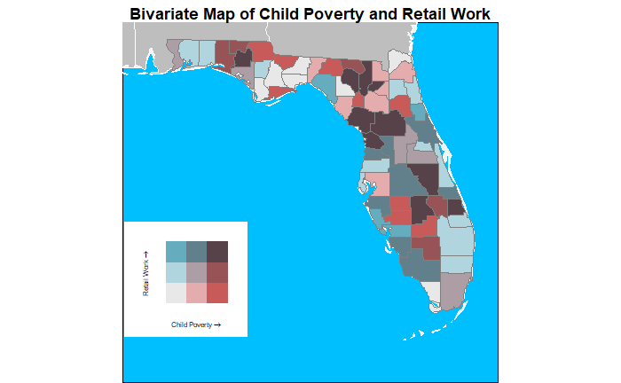

```r
legend_map <- ggdraw() +
  draw_plot(retail_pov_map, 0, 0, 1, 1) +
  draw_plot(legend, -0.000000444, 0.12, 0.6, 0.30)
legend_map
```

[output not shown]